Mesenchymal Stem Cell Therapy

for Osteoradionecrosis of the Mandible: a Systematic Review

of Preclinical and Human Studies

Anders Kierkegaard Gundestrup<sup>1</sup>

& Charlotte Duch Lynggaard<sup>1</sup>& Lone Forner<sup>2</sup>& Terhi J. Heino<sup>3</sup>&

Kathrine Kronberg Jakobsen<sup>1</sup>& Anne Fischer-Nielsen<sup>4</sup>& Christian Grønhøj<sup>1</sup>& Christian von Buchwald<sup>1</sup>

# Springer Science+Business Media, LLC, part of Springer Nature 2020

Abstract

Background Osteoradionecrosis (ORN) of the mandible is a severe complication of radiotherapy for head and neck cancer and is

arduously difficult to manage. Current treatment options carry risks with some patients remaining incurable. Mesenchymal stromal/

stem cell (MSC) therapy has shown promising results supporting osteogenesis and regeneration of radiotherapy-damaged tissues.

The aim of this study was to systematically review the literature on the safety and efficacy of MSCs in treating ORN.

Methods A systematic search was performed on MEDLINE, Embase, Cochranes Library online databases, and clinicaltrials.gov

to identify preclinical and clinical studies examining the effect of MSCs on osseous healing of ORN. The preclinical studies were

assessed according to the SYRCLEs guidelines and risk of bias tool.

Results Six studies (n = 142) from 5 countries were eligible for analysis. Of these four were preclinical studies and two clinical

case studies. Preclinical studies found MSC treatment to be safe, demonstrating bone restorative effects and improved soft tissue

regeneration. In the clinical cases, healing of bone and soft tissue was reported with no serious adverse events.

Conclusion The evidence from the included studies suggests that MSCs may have beneficial regenerative effects on the healing

of ORN. None of the studies reported adverse events with the use of MSCs. More carefully controlled studies with well-identified

cells are however needed to demonstrate the efficacy of MSCs in a clinical setting.

Keywords Osteoradionecrosis <sup>.</sup>Mesenchymal stem cells <sup>.</sup>Cell therapy <sup>.</sup>ORN <sup>.</sup>Systematic review

Introduction

Osteoradionecrosis of the mandible (ORN) is a complication

of high-dose radiotherapy of the head and neck. The currently

accepted definition of the condition is bone devitalization sec-

ondary to radiotherapy, where bone becomes exposed through

the overlying skin or mucosa without healing for three months

in the absence of recurrent tumor [1, 2]. ORN often occurs as a

consequence of local trauma but may also arise spontaneous-

ly, and ranges from small asymptomatic bone exposures to

severe necrosis with pathologic fractures necessitating surgi-

cal intervention and reconstruction [3]. Recently published

data show that ORN affects approximately 5% of patients

who undergo radiotherapy for head and neck cancer [4, 5].

The pathophysiological aetiology of radiation-induced

damage of bone tissue is complex and not fully understood.

In 1983, Marx et al. [6] presented the pathophysiology of

ORN as a hypo-triad; hypoxia, hypocellularity, and

hypovascularity. Consequently, aseptic bone necrosis will de-

velop due to impaired regenerative capacity of the bone and

soft tissue secondary to the radiation-injury and local trauma

[7]. Another theory is that the initial event in developing ORN

is the early radiational damage to osteoclasts, leading to de-

creased osteoclast-related bone turnover, preceding vascular

changes and, ultimately, bone necrosis [8].

* Christian von Buchwald

Christian.von.Buchwald@regionh.dh

1

Department of Otorhinolaryngology, Head and Neck Surgery and

Audiology, Rigshospitalet, University of Copenhagen,

Copenhagen, Denmark

2

Department of Oral and Maxillofacial Surgery, Rigshospitalet,

University of Copenhagen, Copenhagen, Denmark

3

Institute of Biomedicine, Faculty of Medicine, University of Turku,

Turku, Finland

4

Department of Immunology, Cell Therapy Facility, Rigshospitalet,

University of Copenhagen, Copenhagen, Denmark

https://doi.org/10.1007/s12015-020-10034-5

Published online: 1 September 2020

Stem Cell Reviews and Reports (2020) 16:1208–1221

Treatment of mild cases of ORN of the mandible consists

of conservative prevention seeking to avoid further progres-

sion of the disease by good oral hygiene and avoiding predis-

posing factors such as tooth extraction, alcohol, tobacco, and

poor nutritional status [1, 4, 9, 10]. Hyperbaric oxygen treat-

ment (HBO) has proven to hinder further development of

moderate ORN [6, 11, 12]. Severe cases are treated with sur-

gical resection and free flap transplant in combination with

HBO [13]. However, ORN is notoriously difficult to manage

and a considerable percentage of patients remain incurable or

experience recurrent ORN even after successful recovery.

Several studies have recently suggested that treatment with

mesenchymal stromal/stem cells (MSCs) might be a viable

treatment option for ORN of the mandible [14–17].

MSCs are multipotent adult cells first discovered in the

bone marrow (BM) to support haematopoiesis [18]. Since

then, MSCs have been isolated from virtually all connective

tissues where they have been shown to support tissue regen-

eration, as well as respond to injuries and inflammation [19].

MSCs are defined by their ability to adhere to plastic in cell

cultures, positive expression of specific surface markers

(CD90, CD73, CD105) combined with the absence of others

(e.g. CD45 and CD14), and the tri-lineage differentiation ca-

pacity into osteoblasts, adipocytes, and chondroblasts

[20–22]. An important mechanism of action is believed to

be the secretion of bioactive molecules promoting angiogen-

esis, anti-apoptosis, immune modulation, antifibrosis, and

support of local stem cells [21, 23–26]. These properties make

MSCs promising candidates for clinical cell therapy [19] and a

treatment option worth considering in radiation-induced dis-

eases, including ORN [14–17, 24, 27–32].

The above mentioned effects of MSCs could promote regen-

eration and soft tissue healing also in ORN, when taking into

consideration the pathophysiology of the hypo-triad, as pro-

posed by Marx et al. [6]. MSCs also have the capacity to di-

rectly differentiate into bone-forming osteoblasts [33, 34]. This

osteogenic differentiation ability may contribute to the bone

tissue regeneration [21] together with the proposed theory of

decreased osteoclast-related bone turnover, both of which are

needed for restoring the lost bone structure and turnover.

There is an unmet need for new treatments for mandibular

ORN with no systematic reviews providing evidence of the

potential of MSCs. The objective of this review was thus to

assess the safety and efficacy of MSCs on mandibular ORN in

preclinical and human studies and thereby evaluate the poten-

tial use of MSCs for ORN in future human trials.

Methods

This systematic review adheres to the Preferred Reporting

Items for Systematic Reviews and Meta-Analyses

(PRISMA) statement [35]. The approach, method, and search

string were agreed within the author group. We considered

animal studies, which examined the effects of MSCs for

ORN of the mandible versus a control group, and all eligible

human studies regardless of their publication date. Studies

examining the effects of MSCs in combination with other

treatment regimens, studies without original data as well as

preclinical studies without a control group were excluded. The

primary outcome was safety. The secondary outcome was

signs of osseous healing.

Search Strategy

In July 2019, we systematically searched for English and

Scandinavian language articles in MEDLINE, Embase,

Cochrane Library online databases, and ongoing clinical trials

were searched for in clinicaltrials.gov. MEDLINE and

EMBASE were searched using the following keywords

(including MeSH terms): Osteoradionecrosis, mesenchymal

stem cells, MSC, stem cells, bone marrow mesenchymal

stem cells, bone marrow aspirate concentrate, adipose stem

cells, adipose derived stem cells, stem cell transplantation,

mesenchymal progenitor cells, and Wharton’s jelly cells.

The full search terms including all specific search terms, and

the details of the search are described in Appendix. Besides

the search of databases reference lists were evaluated for

further relevant articles.

Data Extraction

Two authors (AG and LF) independently identified studies

against the inclusion criteria to determine the eligibility. The

following information was recorded from included studies

using the Covidence systematic review software (Covidence

2020): year of publication, author, study design, the species

and number of animals used in the study, the graft donor

species, patient demographics, the origin of the MSCs, the

treatment model/intervention, number of cells, statistical tests

used, the method used for inducing osteoradionecrosis, infor-

mation on blinding, allocation, control groups, outcomes, ad-

verse events, and follow-up time.

Data Analysis

The preclinical studies were evaluated according to the

SYRCLEs guidelines and risk of bias tool. The publication

bias was evaluated using funnel plot and small-study effect

using Egger regression.

Results

Six studies published in 2010–2017 met the inclusion criteria

(Fig. 1). Four animal studies (n = 139, intervention groups n =

1209

Stem Cell Rev and Rep (2020) 16:1208–1221

49) (Table 1) and two human case studies (n = 3) (Table 2)

were identified. Clinicaltrials.gov showed one randomised

controlled trial including human ORN cases, which might

have met the inclusion criteria, but the authors of that trial

did not respond to our requests, nor have any results been

published so far. Cochrane Library did not present any

studies meeting our inclusion criteria.

Owing to the limited number and the heterogeneity of the

studies, it was not possible to perform meta-analysis or evaluate

small-study effects using a funnel plot or Egger regression.

Safety of MSC

All studies described the MSC-based cell therapy as safe with no

anaesthesia and complications of producing the bony defect.

The case reports revealed no adverse events or complications.

Description of the Animal Models

Four articles investigated the safety and efficacy of MSCs for

mandibular ORN in a total of 139 animals (intervention

groups n = 49) of different species (Table 1). The research

groups used variations of the same model to mimic ORN, by

radiating the hemimandible with 20–30 Gy, followed by tooth

extraction to induce a bone defect (Table 1). The source of the

MSCs also varied between the studies (Table 1).

The Effect of MSCs on Osseous Healing of the

Mandible in Animal Model ORN

Four animal studies (n = 139) investigated the effect of MSCs

on osseous healing in mandibular ORN (Table 1) [14–17].

Primary outcome of the studies differed. All studies could

demonstrate an increase of osseous healing in animals treated

with MSCs for ORN. Based on micro-CT results, two studies

animals [14, 17]. Two studies found a significant increase of

the bone mineral density (BMD) compared to untreated ani-

mals [15, 17]. Finally, one study found a significant increase

in bone volume/tissue volume (BV/TV) compared to untreat-

ed animals [16].

Histologically, all studies found increased bone formation

in the MSC groups compared to controls. Janus et al. found a

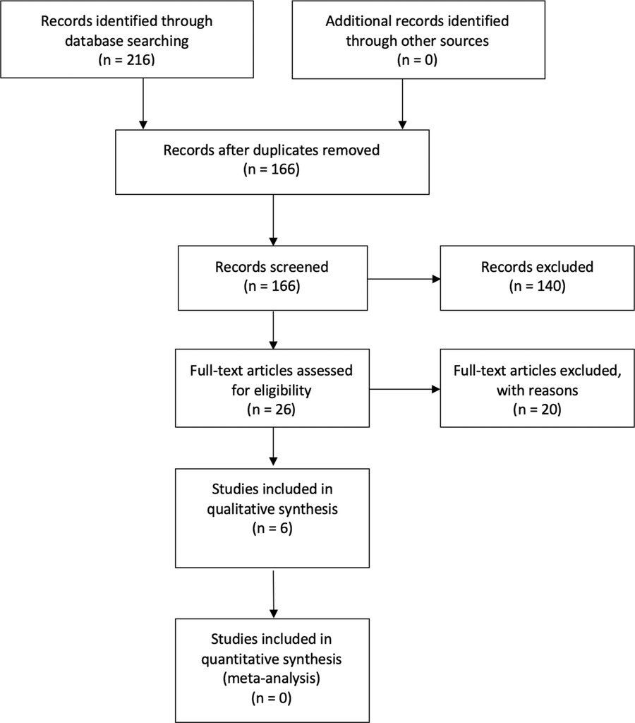

Fig. 1 PRISMA chart showing

the screening process for the

selection of eligible studies

1210

Stem Cell Rev and Rep (2020) 16:1208–1221

Table 1

Animal ORN models

Author (Year)

Animals

Origin of MSCs

Intervention

Groups

Method for ORN

Focus of interest

Statistic tests

Study design

Park HS. et al.

(2017) [15]

Adult male Sprague

Dawley rats

(250 g–300 g)

n = 36

Tonsil derived-MSCs

(TMSCs) from a

5-year old boy who

underwent

tonsillectomy.

Xenograft

Control group received only

tooth extraction, no

radiation. The other rats

are divided into 5 groups.

First group is the ORN

group, receiving both

radiation and tooth

extraction, but no

treatment. Two other

groups underwent same

procedure but received

the received matrigel

directly into the wound of

the tooth extractions, one

group received it

immediately, and one

after 4 weeks. Same for

the last two groups,

although they received

the TMSCs instead of

only matrigel. Animals

were killed 8 weeks after

receiving matrigel

or TMSCs.

1. Control group. Tooth

extraction. (TE) n = 3

2. Radiation therapy

(RT) + TE / ORN n = 4

3. RT + TE + Matrigel

application

immediately. n = 9

4. RT + TE + TMSCs

immediately. n = 6

5. RT + TE + Matrigel

4 weeks post. n = 6

6. RT + TE + TMSCs

4 weeks post. n = 8

Left mandibular body

irradiated with

single dose 20Gy.

One week later,

three left molars

are extracted to

induce ORN.

A study of the effect of

tonsil derived MSCs

for the treatment of

ORN. It is also a

study of the effect of

immediate

application of the

TMSCs, versus

application 4 weeks

post teeth extraction.

Micro-CT, as well as

histological analysis were

conducted. The

micro-CTs were analysed

using the Mann-Whitney

U test, to test for

significance of data. The

histological analyses

were not analysed

statistically.

Controlled trial. The

analysis of the

micro-CT scans

was done

blinded.

Jin IG et al.

(2015) [17]

Seven weeks old

Sprague-Dawley

rats. Avg. weight

205 g. (Originally

114 animals, but 49

lost during

development of

ORN). N = 65.

Bone marrow

mesenchymal stem

cells cultured from

bone marrow

aspirate from

rat tibias.

Allogenous.

Rats were split into two

overall groups apart from

control and pilot

experiments group.

Group 1 received the

implant of hydrogel

loaded with rat MSCs

(rMSCs) or

bone-morphogenetic

protein-2 (BMP-2) or a

combination immediately

after producing the bone

defect. Group 2 received

the loaded hydrogel

4 weeks postoperatively

while also undergoing

curettage. The follow-up

period for the rats were

4 weeks after the

insertion of the hydrogel

i.e. 4 weeks

postoperatively for the

rats in group 1 and

8 weeks for group 2.

1. Control group, surgery,

but no radiation. N = 6

2. Pilot experiments

group, to determine

doses and confirm

ORN development.

N = 9

3. Group 1, radiation, and

defect formation.

Received the hydrogel

immediately.

Subdivisions

a-e below.

4. Group 2, same as gr. 1,

but received hydrogel

4 weeks post-surgery.

Subdivisions a-e below.

a: Defect formation only

(n = 5 each grp.)

b: Hydrogel only

(n = 5 each grp.)

c: Hydrogel loaded

with rMSCs

(n = 5 each grp.)

Single dose of 30 Gy

administered to the

right mandible.

One week later

three right

mandibular molars

were extracted,

and a bony defect

created surgically

to induce the ORN.

The study investigates

the effect of MSCs,

BMP-2 and a

combination, on the

osseous healing in

ORN, at two

different

administration times.

The normality of distribution

for the data confirmed

with the

Kolmogorov-Smirnov

test. Two-way analysis of

variance (ANOVA) with

Bonferroni correction

was used to analyse

effects of application time

and material. One-way

ANOVA was used to

analyse the differences

within the groups.

Groups with abnormal

distribution had the

Kruskal-Wallis test run to

compare CT data. Results

considered significant at

p value of <0,05.

Controlled trial

1211

Stem Cell Rev and Rep (2020) 16:1208–1221

Table 1 (continued)

Author (Year)

Animals

Origin of MSCs

Intervention

Groups

Method for ORN

Focus of interest

Statistic tests

Study design

d: Hydrogel loaded

with BMP-2

(n = 5 each grp.)

e: Hydrogel loaded with

both rMSCs

and BMP-2.

(n = 5 each grp.)

Janus JR et al.

(2017) [14]

7 weeks old athymic

nude rats. N = 23.

Human adipose-derived

mesenchymal stem

cells (ADSCs)

donated by people

who had restorative

surgery for ORN.

Xenograft.

Control group received no

radiation. The other 4

groups received radiation

and tooth extraction

7 days later. 35 days post

irradiation injections of

either saline, ADSCs,

Platelet Rich Plasma/

Collagen (PRP/COL), or

combinations thereof,

were done. 28 days post

injections the rats were

sacrificed for analysis.

1. Control group, no

irradiation n = 4

2. Saline injections n = 5

3. Saline + ADSCs n = 5

4. PRP/COL n = 4 (loss of

1 animal)

5. ADSCs + PRP/COL

n = 5

Left mandible

irradiated with

single dose 20 Gy.

7 days later,

second left molar

was extracted to

induce ORN.

A study to investigate

the regenerative

and restorative

properties of ADSCs

in a validated model

for ORN.

Initial Chi-square analysis,

followed by 2-tailed

t-tests for unpaired

samples for p value

<0,05. Pathologists were

blinded for histological

analysis.

Controlled trial.

Histological

analysis was

done blinded.

Xu J et al.

(2012) [16]

Inbred miniature pigs,

7–8 months old,

25–30 kg. N = 15.

Bone marrow

mesenchymal

stromal cells

(BMMSCs) were

harvested and

cultured from the

ilium of the

irradiated pigs

5 months post

radiation.

Autologous.

No radiation in control

group. The remaining

pigs received irradiation

of the mandibular body,

and two months later had

tooth extraction. The

treatment group received

autologous BMMSCs +

HA/TCP 6 months post

radiation. The control

group received only

HA/TCP at the same

time. Six months

post-transplant i.e. 1 year

after radiation.

1. Control group.

Irradiation, no tooth

extraction. N = 3

2. Sample group, with

tooth extractions, for

observations at set

points. N = 3

3. Treatment group,

transplant of

BMMSCs with

hydroxyapatite/

tricalcium phosphate

(HA/TCP). N = 5

4. Control group with

only HA/TCP

implants. N = 4

Mandibular body

irradiated with a

single dose of

25 Gy. First molar

extracted 2 months

post irradiation.

A study of the effect

of autologous

implantation of

BMMSCs in a swine

ORN model.

Data was analysed

statistically with a

one-way analysis of

variance (ANOVA), with

values compared with

control groups. p value of

<0.05 was significant.

Adjusted by the

Bonferroni method for

multiple comparisons.

Randomly

controlled trial.

1212

Stem Cell Rev and Rep (2020) 16:1208–1221

significant decrease in osteoclasts in MSC, MSC + platelet-

rich-plasma (PRP)/collagen (COL) group, and PRP/COL

groups when compared to saline injections only. They also

found a significant increase in the number of osteoblasts in

MSC + PRP/COL and PRP/COL group, but not in MSC

group [14].

The Administration Time of the MSCs for ORN

Two studies with rats (n = 101) investigated how the

timing of MSC administration altered the outcome of

ORN [15, 17]. Both applied the MSCs either immediately

after producing the bony defect or four weeks later. Jin

et al. [17] found that the application of allogenic rat BM-

MSCs only had a significant improvement in BV and BMD

when applied four weeks after tooth extraction. In contrast,

Park et al. [15] found that only immediate application of

human tonsillar-derived MSCs after extracting teeth

showed a significant improvement in BMD.

The Effect of MSCs on Mandibular ORN in Human Case

Studies

Manimaran et al. [36] introduced a case study with two pa-

tients with confirmed ORN diagnosis treated either with BM

aspirate concentrate (BMAC) or dental pulp stem cells

(DPSCs). The first patient was a 48-year-old male with recur-

ring symptoms of advanced ORN over a period of 1.5 years

(with chronic osteomyelitis and a suspected pathological frac-

ture) following radiotherapy for carcinoma of the soft palate in

combination with tooth extraction. After curettage, this patient

received autologous BMACs via local injection as well as

mixed in a hydroxyapatite/tricalcium phosphate (HA/TCP)

matrix. Two months later the patient showed signs of im-

provement with early bone formation as demonstrated on ra-

diographs, by pain reduction, and cessation of discharge from

the intraoral lesion. Six months after the treatment, there was a

resolution of the suspected pathological fracture. Complete

bone remodeling was noticed in radiographs after one year,

and two years after treatment the patient was still asymptom-

atic with no apparent adverse effects. The second patient, a 47-

year-old male, with a history of radiotherapy for oral cancer,

presented with signs of advanced ORN. The patient was treat-

ed with allogenic DPSCs, extracted from teeth removed for

orthodontic management. Following surgical curettage, un-

specified dose of DPSCs in PRP combined with TCP as a

scaffold was inserted into the defect, and DPSCs in PRP were

also injected into nearby soft tissue. Two months later bone

formation was appreciable, and six months later, clearly no-

ticeable on radiographs. Further follow-up was not reported.

Mendonca et al. [37] presented a case study including one

63-year-old male with severe advanced ORN including intra-

and extraoral fistulas. Before surgical curettage of necrotic

Table 2

Human case studies

Author

Patients

Origin of MSCs

Intervention

ORN diagnosis

Focus of interest

Statistic tests

Mendonca JJ et al.

(2010) [37]

3 Patients, but only one

diagnosed with

ORN, one

63-year-old male

subject. N = 1

Autologous MSCs/

tissue repair cells,

obtained from

patient’s

posterior ileum.

Following the development of advanced

osteoradionecrosis, this patient received an

autologous transplantation of BMMSCs

harvested from the posterior ileum. These were

then concentrated, cultured and prepared for

transplantation with platelet-rich and poor plasma

and HA/TCP. The prepared cells were then

injected into the ORN defect, and surrounding

tissue, following a debridement of necrotic tissue.

Patient diagnosed with advanced

ORN with pathological

fracture, following radiation

treatment of tonsillar cancer,

and a following tooth

extraction. HBO chamber,

antibiotics and other treatment

tried.

Case study of the effects

of MSCs in the treatment of

ORN and other advanced

craniofacial diseases.

No statistical data, as it

is a case study.

Manimaran K. et al.

(2014) [36]

One 48-year-old male

and a 47-year-old

male subject. N = 2

One case (1) with

autologous bone

marrow aspirate

conc. (BMAC).

Second case (2) is

allogenic dental pulp

stem cells (DPSCs).

Case 1 patient received autologous BMMSCs,

harvested from his iliac crest, this was then

concentrated and injected into the socket around

his bone defect. Case 2 patient received allogenic

DPSCs from extracted teeth. Stem cell graft

consisting of PRP and alloplastic graft as scaffold

was inserted into the defect.

ORN diagnosed in the two

patients, as they both have had

oropharyngeal cancers.

A case study of the effect

of MSCs as a

treatment for ORN.

No statistical data.

1213

Stem Cell Rev and Rep (2020) 16:1208–1221

tissue, the patient was treated with an injection of 5 × 10<sup>8</sup>

culture-expanded BM-derived total nuclear cells (TNCs) of

which approx. 36% expressed CD90 [22]. However, approx.

67% of TNCs also expressed CD45, which is a common leu-

cocyte antigen that should be negative in MSCs. The cells

were mixed with PRP and platelet-poor plasma and HA/

TCP, forming a bioactive matrix. As another temporary scaf-

fold, a membrane made by compressing platelet-poor plasma

and injected with cells, was used. Cells were also inoculated

into nearby soft tissues. Three months post-operatively the

patient showed signs of osteogenesis on CT-scans. During a

dental prosthesis procedure, a bone biopsy was performed. It

showed a pure cortical morphology and osteoblast/osteoclast

activity. Twenty-months post-operatively, the patient reported

no complications nor sequelae.

Risk of Bias

The animal studies were assessed using SYRCLEs guidelines

and risk of bias tool with eight questions to determine poten-

tial biases for animal studies [38]. The assessment revealed

risk of bias for all studies: particularly selection bias, as none

of the studies described how the randomization of

intervention/control groups was performed (Fig. 2).

None of the studies reported blinding of investigators, and

none reported random housing. All of the studies had a low

risk of bias concerning attrition and detection bias, but Xu

et al. and Jin et al. did not report blinding of the outcome

assessment [16, 17]. Case reports have a great risk of publica-

tion-bias, as cases with negative results would most likely not

be published, and there are no requirements to report if such

cases exist.

Discussion

We aimed to systematically evaluate MSCs as a treat-

ment for mandibular ORN. Our search identified four

animal studies and two case reports comprising three

patients investigating the efficacy and safety of MSCs

on mandibular ORN. MSC administration was safe and

studies included in this review demonstrated a positive

effect either as an increase in BV or BMD.

There were differences regarding the impact of the MSC

administration time as two animal studies had conflicting

results; one study [15] identified an effect only if the MSCs

were administered immediately after a bony defect was

created, whereas another study [17] showed significant re-

sults, when administering the MSCs four weeks postoper-

atively. The difference might be due to the tissue source,

being xenograft and allogenic respectively, but other dif-

ferences in study design might also influence the results.

The animal studies [14–17] observed soft tissue

regeneration, increased epithelialization and soft tissue

healing with the use of MSCs, although none of the studies

quantitatively verified this effect. Janus et al. found a sig-

nificant increase of fibrosis in all their treatment groups,

compared to control and saline groups [14]. As all groups,

the ones receiving MSCs and the one that did not, showed

this effect, it is unlikely that MSCs, and not some other

confounder, would have caused this outcome. One preclin-

ical study found a significant increase in the density of

microvessels [16], another found the same effect, which

however was not quantified nor blinded [15]. In the clinical

study by Mendonca et al., MRI was used to identify neo-

angiogenesis and a positive angiogenic effect was ob-

served [37]. There are also other previous studies, which

have concluded that MSCs can enhance vasculogenesis

after irradiation-induced tissue damage e.g. in bone [28],

skeletal muscle [32], and colon [27]. Thus, MSCs may be

beneficial in improving hypo-vascularity.

To be identified as MSCs, the cells must meet certain

criteria established by the International Society for Cell &

Gene Therapy, ISCT [22]. The criteria include morphology,

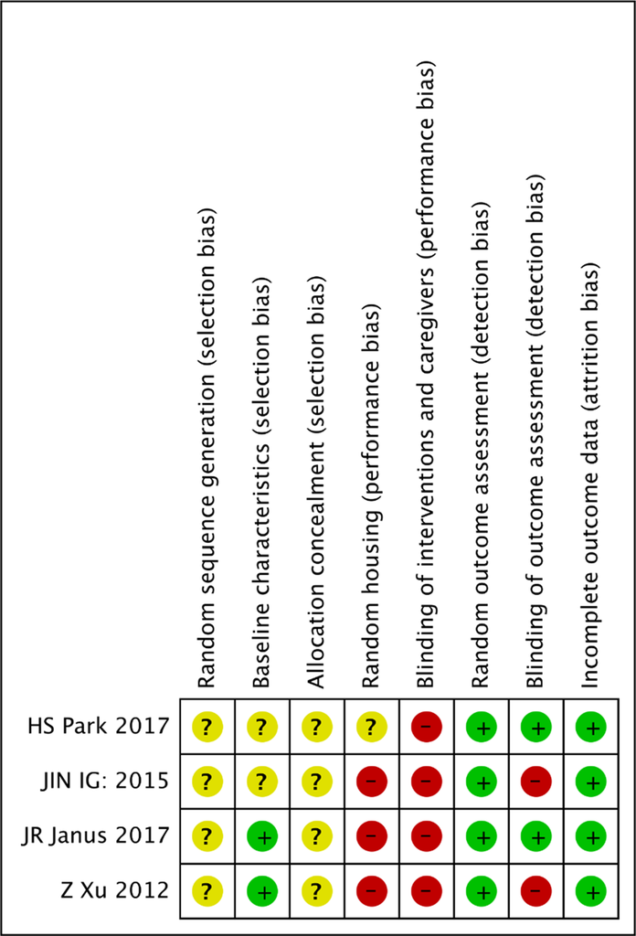

Fig. 2 SYRCLEs Risk of bias assessment tool. (?) = Unclear risk of bias,

(+) = Low risk of bias, (−) = High risk of bias

1214

Stem Cell Rev and Rep (2020) 16:1208–1221

growth kinetics, surface marker expression, plastic adherence,

and multipotential differentiation capacity; however, all these

characteristics are defined by the “golden standard” i.e. BM-

derived MSCs. Therefore, new statements have been made

concerning the adipose tissue derived stromal cells and the

ability of MSCs to influence the immune system [39, 40].

Even though the gross phenotypic appearance, such as marker

expression and differentiation potential would be similar,

MSCs from different tissues and species are not identical

[41]. For example, it has been reported that bone marrow

and adipose tissue derived MSCs differ in gene expression,

angiogenic potential, and secretion of various factors [42].

As the studies included in our systematic review utilized

MSCs from various species and tissues, direct comparisons

are very challenging. Either autologous or allogeneic cells

as well as xenografts were used in the preclinical animal

studies and the cells were originally derived from various

tissues, including bone marrow, tonsils or adipose tissue

(Table 1) [14–17]. In the two human case studies, the cells

and possible culture expansions varied between different

studies, both of which are known to affect the biological

characteristics of MSCs.

In none of the preclinical or clinical case studies, were the

cells fully identified according to the above-defined MSC

criteria. Janus et al. described testing the tri-lineage differen-

tiation potential [14] and Xu et al. performed Stro-1 and

CD146 surface marker expression profiling but no data is

shown. In one of the clinical cases, Mendonca et al. reported

a partial MSC surface marker expression profile with 36% of

cells positive for CD90 and 14% for CD105, but 67% of cells

were positive also for the hematopoietic marker CD45, indi-

cating that only a minority of cells in their study fulfilled the

surface marker criteria for MSCs. Also, in the one clinical case

by Manimaran et al., the cells injected were a very heteroge-

nous cell population from uncultured bone marrow containing

only a minor fraction of MSCs. [43]

In addition, despite of current attempts to unify the MSC

nomenclature [44], there is still discrepancy and confusion in

the current literature. Tissue-derived stromal cells can partially

possess the same properties as MSCs and thus are sometimes

incorrectly stated as “stem cells”. This raises further difficulty

in comparing study outcomes and represents another source of

confusion in cell therapy development.

In addition to the risk of bias identified using the SYRCLEs

risk of bias tool, there is a considerable risk of bias in the

preclinical studies. A lot of methodology regarding selection

and housing of the animals, and blinding/randomization of the

trials is either unreported or executed in a way resulting in

increased risk of bias in the experiments.

The human case studies provide important initial clin-

ical data, although the very limited number of patients,

the lack of control groups, lack of well-characterized

cells, as well as potential bias and blinding precludes

the possibility of detailed, quantitative analysis. The lon-

gest follow-up period was two years, which may not

expose potential long-term side effects. However, these

studies can be used as a model for potential upcoming

human clinical trials.

In conclusion, current preclinical literature suggests that

MSCs are safe with promising positive effects on osseous

and soft tissue regeneration in ORN of the mandible. Our

systematic review furthermore highlights the need for

performing more controlled studies with well-characterized

cells to verify their efficacy.

Acknowledgements Thank you to librarian Jette Meelby at the health

scientific library at Nordsjællands Hospital Hillerød, for help with prep-

aration and development of the search string.

Author Contributions AG, CDL, CG and CvB conceived the study de-

sign. AG, CL and LF were responsible for search preparation, literature

search, article screening and selection. The initial draft of the manuscript

was written by AG and CDL, and all authors critically revised the work.

The final manuscript was read and approved by all authors.

Compliance with Ethical Standards

Conflict of Interest

The authors declare no conflicts of interest.

Appendix

Advanced search strategy

The final search was conducted on the 25th of March 2020.

The EMBASE search revealed 128 studies including all paper

types. These results were imported into Covidence.org 2020

review software for screening. The screening process

flowchart can be seen in Fig. 1.

Cochrane Library was searched with fewer central key-

words in order to identify reviews of interest. The keywords

for condition were:

“osteoradionecrosis” OR “ORN” OR “Osteoradionecrosis

of the jaw” OR “ORNJ” OR “ONJ”.

This search revealed five Cochrane reviews. None of these

reviews investigated the use of mesenchymal stem/stromal

cells as a possible treatment for osteoradionecrosis, and thus

the included studies of the reviews were not included in our

analysis. ClinicalTrials.gov was searched for all trials

including the condition “osteoradionecrosis”. 14 results were

found. Only one trial seemed to fit our inclusion criteria, and

none of the exclusion criteria. However, in that study no

results have been published, and the author did not respond

to our inquiry.

1215

Stem Cell Rev and Rep (2020) 16:1208–1221

Table 3

MEDLINE Search

Osteoradionecrosis

“osteoradionecrosis”[MeSH Terms] OR “osteoradionecrosis”[All Fields]

ONJ

“Open Neuroendocrinol J”[Journal] OR “Open Nanomed J”[Journal] OR “onj”[All Fields]

Mesenchymal stem cells

“mesenchymal stem cells”[MeSH Terms] OR (“mesenchymal”[All Fields] AND “stem”[All

Fields] AND “cells”[All Fields]) OR “mesenchymal stem cells”[All Fields]

Mesenchymal stem cell

“mesenchymal stem cells”[MeSH Terms] OR (“mesenchymal”[All Fields] AND “stem”[All

Fields] AND “cells”[All Fields]) OR “mesenchymal stem cells”[All Fields] OR

(“mesenchymal”[All Fields] AND “stem”[All Fields] AND “cell”[All Fields]) OR

“mesenchymal stem cell”[All Fields]

Mesenchymal stromal cells

“mesenchymal stem cells”[MeSH Terms] OR (“mesenchymal”[All Fields] AND “stem”[All

Fields] AND “cells”[All Fields]) OR “mesenchymal stem cells”[All Fields] OR

(“mesenchymal”[All Fields] AND “stromal”[All Fields] AND “cells”[All Fields]) OR

“mesenchymal stromal cells”[All Fields]

Mesenchymal stromal cell

“mesenchymal stem cells”[MeSH Terms] OR (“mesenchymal”[All Fields] AND “stem”[All

Fields] AND “cells”[All Fields]) OR “mesenchymal stem cells”[All Fields] OR

(“mesenchymal”[All Fields] AND “stromal”[All Fields] AND “cell”[All Fields]) OR

“mesenchymal stromal cell”[All Fields]

Stem cell

“stem cells”[MeSH Terms] OR (“stem”[All Fields] AND “cells”[All Fields]) OR “stem cells”[All

Fields] OR (“stem”[All Fields] AND “cell”[All Fields]) OR “stem cell”[All Fields]

Stem cells

“stem cells”[MeSH Terms] OR (“stem”[All Fields] AND “cells”[All Fields]) OR “stem cells”[All

Fields]

Mesenchymal stem cell transplantation

“mesenchymal stem cell transplantation”[MeSH Terms] OR (“mesenchymal”[All Fields] AND

“stem”[All Fields] AND “cell”[All Fields] AND “transplantation”[All Fields]) OR

“mesenchymal stem cell transplantation”[All Fields]

Stem cell transplantation

“stem cell transplantation”[MeSH Terms] OR (“stem”[All Fields] AND “cell”[All Fields] AND

“transplantation”[All Fields]) OR “stem cell transplantation”[All Fields]

Bone marrow

“bone marrow”[MeSH Terms] OR (“bone”[All Fields] AND “marrow”[All Fields]) OR “bone

marrow”[All Fields]

Bone marrow mesenchymal stem cells

“mesenchymal stem cells”[MeSH Terms] OR (“mesenchymal”[All Fields] AND “stem”[All

Fields] AND “cells”[All Fields]) OR “mesenchymal stem cells”[All Fields] OR (“bone”[All

Fields] AND “marrow”[All Fields] AND “mesenchymal”[All Fields] AND “stem”[All Fields]

AND “cells”[All Fields]) OR “bone marrow mesenchymal stem cells”[All Fields]

Stem Cell, Mesenchymal

“mesenchymal stem cells”[MeSH Terms] OR (“mesenchymal”[All Fields] AND “stem”[All

Fields] AND “cells”[All Fields]) OR “mesenchymal stem cells”[All Fields] OR (“stem”[All

Fields] AND “cell”[All Fields] AND “mesenchymal”[All Fields])

Stem Cells, Mesenchymal

“mesenchymal stem cells”[MeSH Terms] OR (“mesenchymal”[All Fields] AND “stem”[All

Fields] AND “cells”[All Fields]) OR “mesenchymal stem cells”[All Fields] OR (“stem”[All

Fields] AND “cells”[All Fields] AND “mesenchymal”[All Fields]) OR “stem cells,

mesenchymal”[All Fields]

Bone Marrow Stromal Cells

“mesenchymal stem cells”[MeSH Terms] OR (“mesenchymal”[All Fields] AND “stem”[All

Fields] AND “cells”[All Fields]) OR “mesenchymal stem cells”[All Fields] OR (“bone”[All

Fields] AND “marrow”[All Fields] AND “stromal”[All Fields] AND “cells”[All Fields]) OR

“bone marrow stromal cells”[All Fields]

Bone Marrow Stromal Cell

“mesenchymal stem cells”[MeSH Terms] OR (“mesenchymal”[All Fields] AND “stem”[All

Fields] AND “cells”[All Fields]) OR “mesenchymal stem cells”[All Fields] OR (“bone”[All

Fields] AND “marrow”[All Fields] AND “stromal”[All Fields] AND “cell”[All Fields]) OR

“bone marrow stromal cell”[All Fields]

Bone Marrow Stromal Cells, Multipotent

“mesenchymal stem cells”[MeSH Terms] OR (“mesenchymal”[All Fields] AND “stem”[All

Fields] AND “cells”[All Fields]) OR “mesenchymal stem cells”[All Fields] OR (“bone”[All

Fields] AND “marrow”[All Fields] AND “stromal”[All Fields] AND “cells”[All Fields] AND

“multipotent”[All Fields])

Multipotent Bone Marrow Stromal Cells

“mesenchymal stem cells”[MeSH Terms] OR (“mesenchymal”[All Fields] AND “stem”[All

Fields] AND “cells”[All Fields]) OR “mesenchymal stem cells”[All Fields] OR

(“multipotent”[All Fields] AND “bone”[All Fields] AND “marrow”[All Fields] AND

“stromal”[All Fields] AND “cells”[All Fields]) OR “multipotent bone marrow stromal

cells”[All Fields]

Adipose-Derived Mesenchymal Stem Cells

“mesenchymal stem cells”[MeSH Terms] OR (“mesenchymal”[All Fields] AND “stem”[All

Fields] AND “cells”[All Fields]) OR “mesenchymal stem cells”[All Fields] OR (“adipose”[All

Fields] AND “derived”[All Fields] AND “mesenchymal”[All Fields] AND “stem”[All Fields]

AND “cells”[All Fields]) OR “adipose derived mesenchymal stem cells”[All Fields]

Adipose Derived Mesenchymal Stem Cells

“mesenchymal stem cells”[MeSH Terms] OR (“mesenchymal”[All Fields] AND “stem”[All

Fields] AND “cells”[All Fields]) OR “mesenchymal stem cells”[All Fields] OR (“adipose”[All

Fields] AND “derived”[All Fields] AND “mesenchymal”[All Fields] AND “stem”[All Fields]

AND “cells”[All Fields]) OR “adipose derived mesenchymal stem cells”[All Fields]

Mesenchymal Stem Cells, Adipose-Derived

“mesenchymal stem cells”[MeSH Terms] OR (“mesenchymal”[All Fields] AND “stem”[All

Fields] AND “cells”[All Fields]) OR “mesenchymal stem cells”[All Fields] OR

(“mesenchymal”[All Fields] AND “stem”[All Fields] AND “cells”[All Fields] AND

“adipose”[All Fields] AND “derived”[All Fields])

1216

Stem Cell Rev and Rep (2020) 16:1208–1221

Table 3 (continued)

Mesenchymal Stem Cells, Adipose Derived

“mesenchymal stem cells”[MeSH Terms] OR (“mesenchymal”[All Fields] AND “stem”[All

Fields] AND “cells”[All Fields]) OR “mesenchymal stem cells”[All Fields] OR

(“mesenchymal”[All Fields] AND “stem”[All Fields] AND “cells”[All Fields] AND

“adipose”[All Fields] AND “derived”[All Fields])

Adipose-Derived Mesenchymal Stromal Cells

“mesenchymal stem cells”[MeSH Terms] OR (“mesenchymal”[All Fields] AND “stem”[All

Fields] AND “cells”[All Fields]) OR “mesenchymal stem cells”[All Fields] OR

(“adipose”[All Fields] AND “derived”[All Fields] AND “mesenchymal”[All Fields] AND

“stromal”[All Fields] AND “cells”[All Fields]) OR “adipose derived mesenchymal stromal

cells”[All Fields]

Adipose Derived Mesenchymal Stromal Cells

“mesenchymal stem cells”[MeSH Terms] OR (“mesenchymal”[All Fields] AND “stem”[All

Fields] AND “cells”[All Fields]) OR “mesenchymal stem cells”[All Fields] OR

(“adipose”[All Fields] AND “derived”[All Fields] AND “mesenchymal”[All Fields] AND

“stromal”[All Fields] AND “cells”[All Fields]) OR “adipose derived mesenchymal stromal

cells”[All Fields]

Adipose Tissue-Derived Mesenchymal Stem

Cells

“mesenchymal stem cells”[MeSH Terms] OR (“mesenchymal”[All Fields] AND “stem”[All

Fields] AND “cells”[All Fields]) OR “mesenchymal stem cells”[All Fields] OR

(“adipose”[All Fields] AND “tissue”[All Fields] AND “derived”[All Fields] AND

“mesenchymal”[All Fields] AND “stem”[All Fields] AND “cells”[All Fields]) OR “adipose

tissue derived mesenchymal stem cells”[All Fields]

Adipose Tissue Derived Mesenchymal Stem

Cells

“mesenchymal stem cells”[MeSH Terms] OR (“mesenchymal”[All Fields] AND “stem”[All

Fields] AND “cells”[All Fields]) OR “mesenchymal stem cells”[All Fields] OR

(“adipose”[All Fields] AND “tissue”[All Fields] AND “derived”[All Fields] AND

“mesenchymal”[All Fields] AND “stem”[All Fields] AND “cells”[All Fields]) OR “adipose

tissue derived mesenchymal stem cells”[All Fields]

Adipose Tissue-Derived Mesenchymal

Stromal Cells

“mesenchymal stem cells”[MeSH Terms] OR (“mesenchymal”[All Fields] AND “stem”[All

Fields] AND “cells”[All Fields]) OR “mesenchymal stem cells”[All Fields] OR

(“adipose”[All Fields] AND “tissue”[All Fields] AND “derived”[All Fields] AND

“mesenchymal”[All Fields] AND “stromal”[All Fields] AND “cells”[All Fields]) OR

“adipose tissue derived mesenchymal stromal cells”[All Fields]

Adipose Tissue Derived Mesenchymal

Stromal Cells

“mesenchymal stem cells”[MeSH Terms] OR (“mesenchymal”[All Fields] AND “stem”[All

Fields] AND “cells”[All Fields]) OR “mesenchymal stem cells”[All Fields] OR

(“adipose”[All Fields] AND “tissue”[All Fields] AND “derived”[All Fields] AND

“mesenchymal”[All Fields] AND “stromal”[All Fields] AND “cells”[All Fields]) OR

“adipose tissue derived mesenchymal stromal cells”[All Fields]

Stromal Cell, Mesenchymal

“mesenchymal stem cells”[MeSH Terms] OR (“mesenchymal”[All Fields] AND “stem”[All

Fields] AND “cells”[All Fields]) OR “mesenchymal stem cells”[All Fields] OR

(“stromal”[All Fields] AND “cell”[All Fields] AND “mesenchymal”[All Fields]) OR

“stromal cell, mesenchymal”[All Fields]

Stromal Cells, Mesenchymal

“mesenchymal stem cells”[MeSH Terms] OR (“mesenchymal”[All Fields] AND “stem”[All

Fields] AND “cells”[All Fields]) OR “mesenchymal stem cells”[All Fields] OR

(“stromal”[All Fields] AND “cells”[All Fields] AND “mesenchymal”[All Fields])

Multipotent Mesenchymal Stromal Cells

“mesenchymal stem cells”[MeSH Terms] OR (“mesenchymal”[All Fields] AND “stem”[All

Fields] AND “cells”[All Fields]) OR “mesenchymal stem cells”[All Fields] OR

(“multipotent”[All Fields] AND “mesenchymal”[All Fields] AND “stromal”[All Fields]

AND “cells”[All Fields]) OR “multipotent mesenchymal stromal cells”[All Fields]

Mesenchymal Stromal Cells, Multipotent

“mesenchymal stem cells”[MeSH Terms] OR (“mesenchymal”[All Fields] AND “stem”[All

Fields] AND “cells”[All Fields]) OR “mesenchymal stem cells”[All Fields] OR

(“mesenchymal”[All Fields] AND “stromal”[All Fields] AND “cells”[All Fields] AND

“multipotent”[All Fields])

Mesenchymal Progenitor Cell

“mesenchymal stem cells”[MeSH Terms] OR (“mesenchymal”[All Fields] AND “stem”[All

Fields] AND “cells”[All Fields]) OR “mesenchymal stem cells”[All Fields] OR

(“mesenchymal”[All Fields] AND “progenitor”[All Fields] AND “cell”[All Fields]) OR

“mesenchymal progenitor cell”[All Fields]

Mesenchymal Progenitor Cells

“mesenchymal stem cells”[MeSH Terms] OR (“mesenchymal”[All Fields] AND “stem”[All

Fields] AND “cells”[All Fields]) OR “mesenchymal stem cells”[All Fields] OR

(“mesenchymal”[All Fields] AND “progenitor”[All Fields] AND “cells”[All Fields]) OR

“mesenchymal progenitor cells”[All Fields]

Progenitor Cell, Mesenchymal

“mesenchymal stem cells”[MeSH Terms] OR (“mesenchymal”[All Fields] AND “stem”[All

Fields] AND “cells”[All Fields]) OR “mesenchymal stem cells”[All Fields] OR

(“progenitor”[All Fields] AND “cell”[All Fields] AND “mesenchymal”[All Fields])

Progenitor Cells, Mesenchymal

“mesenchymal stem cells”[MeSH Terms] OR (“mesenchymal”[All Fields] AND “stem”[All

Fields] AND “cells”[All Fields]) OR “mesenchymal stem cells”[All Fields] OR

(“progenitor”[All Fields] AND “cells”[All Fields] AND “mesenchymal”[All Fields])

1217

Stem Cell Rev and Rep (2020) 16:1208–1221

Table 3 (continued)

Wharton Jelly Cells

“mesenchymal stem cells”[MeSH Terms] OR (“mesenchymal”[All Fields] AND “stem”[All

Fields] AND “cells”[All Fields]) OR “mesenchymal stem cells”[All Fields] OR

(“wharton”[All Fields] AND “jelly”[All Fields] AND “cells”[All Fields]) OR “wharton jelly

cells”[All Fields]

Wharton’s Jelly Cells

“mesenchymal stem cells”[MeSH Terms] OR (“mesenchymal”[All Fields] AND “stem”[All

Fields] AND “cells”[All Fields]) OR “mesenchymal stem cells”[All Fields] OR

(“wharton’s”[All Fields] AND “jelly”[All Fields] AND “cells”[All Fields]) OR “wharton’s

jelly cells”[All Fields]

Wharton’s Jelly Cell

“mesenchymal stem cells”[MeSH Terms] OR (“mesenchymal”[All Fields] AND “stem”[All

Fields] AND “cells”[All Fields]) OR “mesenchymal stem cells”[All Fields] OR

(“wharton’s”[All Fields] AND “jelly”[All Fields] AND “cell”[All Fields]) OR “wharton’s

jelly cell”[All Fields]

Whartons Jelly Cells

“mesenchymal stem cells”[MeSH Terms] OR (“mesenchymal”[All Fields] AND “stem”[All

Fields] AND “cells”[All Fields]) OR “mesenchymal stem cells”[All Fields] OR

(“whartons”[All Fields] AND “jelly”[All Fields] AND “cells”[All Fields]) OR “whartons

jelly cells”[All Fields]

Bone Marrow Stromal Stem Cells

“mesenchymal stem cells”[MeSH Terms] OR (“mesenchymal”[All Fields] AND “stem”[All

Fields] AND “cells”[All Fields]) OR “mesenchymal stem cells”[All Fields] OR (“bone”[All

Fields] AND “marrow”[All Fields] AND “stromal”[All Fields] AND “stem”[All Fields]

AND “cells”[All Fields]) OR “bone marrow stromal stem cells”[All Fields]

Table 4

Embase Search

1. ORN.mp. [mp = title, abstract, heading word, drug trade name, original title, device manufacturer, drug manufacturer, device trade name, keyword,

floating subheading word, candidate term word]

2. ORNJ.mp. [mp = title, abstract, heading word, drug trade name, original title, device manufacturer, drug manufacturer, device trade name, keyword,

floating subheading word, candidate term word]

3. ONJ.mp. [mp = title, abstract, heading word, drug trade name, original title, device manufacturer, drug manufacturer, device trade name, keyword,

floating subheading word, candidate term word]

4. Mesenchymal stem cells.mp. or exp. mesenchymal stem cell/

5. Mesenchymal stem cell.mp. or exp. mesenchymal stem cell/ or exp. stem cell/ or exp. mesenchyme cell/

6. Mesenchymal stromal cells.mp. or exp. mesenchymal stroma cell/

7. Mesenchymal stromal cell.mp. or exp. mesenchymal stroma cell/

8. MSC.mp. [mp = title, abstract, heading word, drug trade name, original title, device manufacturer, drug manufacturer, device trade name, keyword,

floating subheading word, candidate term word]

9. MSCs.mp. [mp = title, abstract, heading word, drug trade name, original title, device manufacturer, drug manufacturer, device trade name, keyword,

floating subheading word, candidate term word]

10. Stem cell.mp. or exp. stem cell/

11. Stem cells.mp. or exp. stem cell/

12. Mesenchymal stem cell transplantation.mp. or exp. bone marrow transplantation/ or exp. mesenchymal stem cell transplantation/

13. Stem cell transplantation.mp. or exp. bone marrow transplantation/ or exp. stem cell transplantation/

14. Bone marrow aspirate concentrate.mp.

15. BMAC.mp. [mp = title, abstract, heading word, drug trade name, original title, device manufacturer, drug manufacturer, device trade name, keyword,

floating subheading word, candidate term word]

16. Bone marrow mesenchymal stem cell.mp. or exp. bone marrow derived mesenchymal stem cell/

17. Bone marrow mesenchymal stem cells.mp. or exp. bone marrow derived mesenchymal stem cell/

18. exp. mesenchymal stroma cell/ or exp. bone marrow cell/ or Bone marrow mesenchymal stromal cell.mp. or exp. mesenchymal stem cell/

19. exp. mesenchymal stroma cell/ or Bone marrow mesenchymal stromal cells.mp. or exp. mesenchymal stem cell/

20. BMMSC.mp. [mp = title, abstract, heading word, drug trade name, original title, device manufacturer, drug manufacturer, device trade name,

keyword, floating subheading word, candidate term word]

21. BMMSCs.mp. [mp = title, abstract, heading word, drug trade name, original title, device manufacturer, drug manufacturer, device trade name,

keyword, floating subheading word, candidate term word]

1218

Stem Cell Rev and Rep (2020) 16:1208–1221

References

1.

Chronopoulos, A., Zarra, T., Ehrenfeld, M., & Otto, S. (2018,

February 1). Osteoradionecrosis of the jaws: Definition, epidemiol-

ogy, staging and clinical and radiological findings, A concise re-

view. International Dental Journal. Wiley-Blackwell Publishing

Ltd., 68, 22–30. https://doi.org/10.1111/idj.12318.

2.

Støre, G., & Boysen, M. (2000). Mandibular osteoradionecrosis:

Clinical behaviour and diagnostic aspects. Clinical

Otolaryngology and Allied Sciences, 25(5), 378–384. https://doi.

org/10.1046/j.1365-2273.2000.00367.x.

3.

Danielsson, D., Gahm, C., Haghdoost, S., Munck-Wikland, E., &

Halle, M. (2020). Osteoradionecrosis, an increasing indication for

microvascular head and neck reconstruction. International Journal

of Oral and Maxillofacial Surgery, 49(1), 1–6. https://doi.org/10.

1016/j.ijom.2019.06.009.

4.

Aarup-Kristensen, S., Hansen, C. R., Forner, L., Brink, C., Eriksen,

J. G., & Johansen, J. (2019). Osteoradionecrosis of the mandible

after radiotherapy for head and neck cancer: Risk factors and dose-

volume correlations. Acta Oncologica, 0(0), 1–5. https://doi.org/10.

1080/0284186x.2019.1643037, 58.

5.

Shaw, R. J., Butterworth, C. J., Silcocks, P., Tesfaye, B. T.,

Bickerstaff, M., Jackson, R., Kanatas, A., Nixon, P., McCaul, J.,

Praveen, P., Lowe, T., Blanco-Guzman, M., Forner, L., Brennan,

P., Fardy, M., Parkin, R., Smerdon, G., Stephenson, R., Cope, T., &

Glover, M. (2019). HOPON (hyperbaric oxygen for the prevention

of Osteoradionecrosis): A randomized controlled trial of hyperbaric

oxygen to prevent Osteoradionecrosis of the irradiated mandible

after Dentoalveolar surgery. International Journal of Radiation

Oncology*Biology*Physics, 104(3), 530–539. https://doi.org/10.

1016/j.ijrobp.2019.02.044.

6.

Marx, R. E. (1983). Osteoradionecrosis: A new concept of its path-

ophysiology. Journal of Oral and Maxillofacial Surgery, 41(5),

283–288. https://doi.org/10.1016/0278-2391(83)90294-X.

7.

Rivero, J. A., Shamji, O., & Kolokythas, A. (2017).

Osteoradionecrosis: a review of pathophysiology, prevention and

pharmacologic management using pentoxifylline, α-tocopherol,

Table 4 (continued)

22. Stem Cell, Mesenchymal.mp. [mp = title, abstract, heading word, drug trade name, original title, device manufacturer, drug manufacturer, device

trade name, keyword, floating subheading word, candidate term word]

23. Stem Cell, Mesenchymal.mp. or exp. mesenchymal stem cell/

24. exp. stem cell transplantation/ or exp. mesenchymal stem cell/ or Stem Cells, Mesenchymal.mp.

25. Bone Marrow Stromal Cells.mp. or exp. bone marrow stroma cell/

26. Bone Marrow Stromal Cell.mp. or exp. bone marrow stroma cell/

27. exp. mesenchymal stroma cell/ or Bone Marrow Stromal Cells, Multipotent.mp.

28. Multipotent Bone Marrow Stromal Cells.mp. or exp. bone marrow stroma cell/

29. exp. mesenchymal stem cell/ or Adipose-Derived Mesenchymal Stem Cells.mp. or exp. adipose derived stem cell/

30. exp. stem cell/ or exp. adipose derived stem cell/ or exp. mesenchymal stem cell/ or Adipose Derived Mesenchymal Stem Cells.mp.

31. exp. bone marrow derived mesenchymal stem cell/ or exp. adipose derived stem cell/ or exp. stem cell transplantation/ or Mesenchymal Stem Cells,

Adipose-Derived.mp. or exp. mesenchymal stem cell/

32. exp. mesenchymal stem cell/ or Mesenchymal Stem Cells, Adipose Derived.mp. or exp. stem cell transplantation/ or exp. adipose derived stem cell/

33. exp. mesenchymal stroma cell/ or Adipose-Derived Mesenchymal Stromal Cells.mp. or exp. adipose derived stem cell/

34. exp. mesenchymal stroma cell/ or Adipose Derived Mesenchymal Stromal Cells.mp. or exp. adipose derived stem cell/

35. exp. mesenchymal stem cell/ or Adipose Tissue-Derived Mesenchymal Stem Cells.mp.

36. exp. mesenchymal stem cell/ or Adipose Tissue Derived Mesenchymal Stem Cells.mp.

37. exp. mesenchymal stroma cell/ or Adipose Tissue-Derived Mesenchymal Stromal Cells.mp.

38. exp. mesenchymal stroma cell/ or Adipose Tissue Derived Mesenchymal Stromal Cells.mp.

39. ADMSC.mp. [mp = title, abstract, heading word, drug trade name, original title, device manufacturer, drug manufacturer, device trade name,

keyword, floating subheading word, candidate term word]

40. ADMSCs.mp. [mp = title, abstract, heading word, drug trade name, original title, device manufacturer, drug manufacturer, device trade name,

keyword, floating subheading word, candidate term word]

41. exp. mesenchymal stroma cell/ or exp. mesenchymal stem cell/ or Stromal Cell, Mesenchymal.mp.

42. exp. mesenchymal stroma cell/ or exp. mesenchymal stem cell/ or Stromal Cells, Mesenchymal.mp.

43. exp. mesenchymal stroma cell/ or exp. multipotent stem cell/ or Multipotent Mesenchymal Stromal Cells.mp.

44. exp. mesenchymal stroma cell/ or exp. mesenchymal stem cell/ or Mesenchymal Stromal Cells, Multipotent.mp.

45. Mesenchymal Progenitor Cell.mp. or mesenchymal stem cell/

46. Mesenchymal Progenitor Cells.mp. or exp. mesenchymal stem cell/

47. exp. mesenchymal stem cell/ or exp. stem cell/ or Progenitor Cell, Mesenchymal.mp.

48. exp. mesenchymal stem cell/ or Progenitor Cells, Mesenchymal.mp. or exp. stem cell transplantation/

49. Wharton Jelly Cells.mp. or exp. mesenchymal stroma cell/

50. exp. mesenchymal stem cell/ or exp. mesenchymal stroma cell/ or exp. Wharton jelly/ or Wharton’s Jelly Cells.mp.

51. exp. mesenchymal stem cell/ or exp. mesenchymal stroma cell/ or exp. Wharton jelly/ or Wharton’s Jelly Cell.mp.

52. exp. mesenchymal stem cell/ or exp. mesenchymal stroma cell/ or exp. Wharton jelly/ or Whartons Jelly Cells.mp.

53. exp. bone marrow stroma cell/ or Bone Marrow Stromal Stem Cells.mp.

54. 4 or 5 or 6 or 7 or 8 or 9 or 10 or 11 or 12 or 13 or 14 or 15 or 16 or 17 or 18 or 19 or 20 or 21 or 22 or 23 or 24 or 25 or 26 or 27 or 28 or 29 or 30 or 31

or 32 or 33 or 34 or 35 or 36 or 37 or 38 or 39 or 40 or 41 or 42 or 43 or 44 or 45 or 46 or 47 or 48 or 49 or 50 or 51 or 52 or 53

55. Osteoradionecrosis.mp.

56. 1 or 2 or 3 or 55

57. 54 and 56

1219

Stem Cell Rev and Rep (2020) 16:1208–1221

and clodronate. In Oral Surgery, Oral Medicine, Oral Pathology

and Oral Radiology. Elsevier Inc. https://doi.org/10.1016/j.oooo.

2017.08.004.

8.

Jacobson, A. S., Buchbinder, D., Hu, K., & Urken, M. L. (2010).

Paradigm shifts in the management of osteoradionecrosis of the

mandible. Oral Oncology, 46(11), 795–801. https://doi.org/10.

1016/j.oraloncology.2010.08.007.

9.

Pereira, I. F., Firmino, R. T., Meira, H. C., Egito, V., Do, B. C.,

Vladimir-Reimar-Augusto-De Souza, N., & Santos, V. R. (2018).

Osteoradionecrosis prevalence and associated factors: A ten years

retrospective study. Medicina Oral Patologia Oral y Cirugia

Bucal, 23(6), e633–e638. https://doi.org/10.4317/medoral.22310.

10.

Moon, D. H., Moon, S. H., Wang, K., Weissler, M. C., Hackman,

T. G., Zanation, A. M., Thorp, B. D., Patel, S. N., Zevallos, J. P.,

Marks, L. B., & Chera, B. S. (2017). Incidence of, and risk factors

for, mandibular osteoradionecrosis in patients with oral cavity and

oropharynx cancers. Oral Oncology, 72, 98–103. https://doi.org/10.

1016/j.oraloncology.2017.07.014.

11.

Marx, R. E. (1983). A new concept in the treatment of

osteoradionecrosis. Journal of oral and maxillofacial surgery :

official journal of the American Association of Oral and

Maxillofacial Surgeons, 41(6), 351–357. https://doi.org/10.1016/

s0278-2391(83)80005-6.

12.

Bennett, M. H., Feldmeier, J., Hampson, N. B., Smee, R., &

Milross, C. (2016, April 28). Hyperbaric oxygen therapy for late

radiation tissue injury. In Cochrane Database of Systematic

Reviews. John Wiley and Sons Ltd. https://doi.org/10.1002/

14651858.CD005005.pub4.

13.

Dhanda, J., Pasquier, D., Newman, L., & Shaw, R. (2016). Current

concepts in Osteoradionecrosis after head and neck radiotherapy.

Clinical Oncology, 28(7), 459–466. https://doi.org/10.1016/j.clon.

2016.03.002.

14.

Janus, J. R., Jackson, R. S., Lees, K. A., Voss, S. G., Wilson, Z. C.,

Remmes, N. B., Keeney, M. G., Garcia, J. J., & San Marina, S.

(2017). Human adipose-derived Mesenchymal stem cells for osse-

ous rehabilitation of induced Osteoradionecrosis: A rodent model.

Otolaryngology - Head and Neck Surgery (United States), 156(4),

616–621. https://doi.org/10.1177/0194599816688647.

15.

Park, H. S., Lee, J., Kim, J.-W. W., Kim, H. S. Y. S. Y. S., Jung, S.

Y., Lee, S. M., et al. (2018). Preventive effects of tonsil-derived

mesenchymal stem cells on osteoradionecrosis in a rat model. Head

and Neck, 40(3), 526–535. https://doi.org/10.1002/hed.25004.

16.

Xu, J., Zheng, Z., Fang, D., Gao, R., Liu, Y., Fan, Z., et al. (2012).

Mesenchymal stromal cell-based treatment of jaw

osteoradionecrosis in swine. Cell Transplantation, 21(8), 1679–

1686. https://doi.org/10.3727/096368911X637434.

17.

Jin, I. G., Kim, J. H., Wu, H. G., Kim, S. K., Park, Y., Hwang, S. J.,

et al. (2015). Effect of bone marrow-derived stem cells and bone

morphogenetic protein-2 on treatment of osteoradionecrosis in a rat

model. Journal of Cranio-Maxillofacial Surgery, 43(8), 1478–

1486. https://doi.org/10.1016/j.jcms.2015.06.035.

18.

Friedenstein, A. J., Petrakova, K. V., Kurolesova, A. I., & Frolova,

G. P. (1968). Heterotopic of bone marrow. Analysis of precursor

cells for osteogenic and hematopoietic tissues. In Transplantation :

Official journal of the Transplantation Society. Baltimore, Md.:

Lippott Williams and Wilkins.

19.

Singer, N. G., & Caplan, A. I. (2011). Mesenchymal stem cells:

Mechanisms of inflammation. Annual Review of Pathology:

Mechanisms of Disease, 6(1), 457–478. https://doi.org/10.1146/

annurev-pathol-011110-130230.

20.

Caplan, A. (1991). Mesenchymal stem cells. Journal of

Orthopaedic Research : Official Publication of the Orthopaedic

Research Society, 9(5), 641–650. https://doi.org/10.1002/jor.

1100090504.

21.

da Silva Meirelles, L., Fontes, A. M., Covas, D. T., & Caplan, A. I.

(2009). Mechanisms involved in the therapeutic properties of

mesenchymal stem cells. Cytokine & Growth Factor Reviews,

20(5–6), 419–427. https://doi.org/10.1016/j.cytogfr.2009.10.002.

22.

Dominici, M., Le Blanc, K., Mueller, I., Slaper-Cortenbach, I.,

Marini, F. . C., Krause, D. S. S., … Horwitz, E. M. M. (2006).

Minimal criteria for defining multipotent mesenchymal stromal

cells. The International Society for Cellular Therapy position state-

ment. Cytotherapy, 8(4), 315–317. https://doi.org/10.1080/

14653240600855905.

23.

Caplan, A. I. (2017). Mesenchymal stem cells: Time to change the

name! Stem Cells Translational Medicine, 6(6), 1445–1451. https://

doi.org/10.1002/sctm.17-0051.

24.

Squillaro, T., Peluso, G., & Galderisi, U. (2016). Clinical trials with

Mesenchymal stem cells: An update. Cell Transplantation, 25(5),

829–848. https://doi.org/10.3727/096368915X689622.

25.

Ankrum, J. A., Ong, J. F., & Karp, J. M. (2014, March).

Mesenchymal stem cells: Immune evasive, not immune privileged.

Nature Biotechnology. NIH Public Access., 32, 252–260. https://

doi.org/10.1038/nbt.2816.

26.

Prockop, D. J. (2017). The exciting prospects of new therapies with

mesenchymal stromal cells. Cytotherapy. NIH Public Access., 19,

1–8. https://doi.org/10.1016/j.jcyt.2016.09.008.

27.

Van de Putte, D., Demarquay, C., Van Daele, E., Moussa, L.,

Vanhove, C., Benderitter, M., et al. (2017). Adipose-derived

Mesenchymal stromal cells improve the healing of colonic anasto-

moses following high dose of irradiation through anti-inflammatory

and Angiogenic processes. Cell Transplantation, 26(12), 1919–

1930. https://doi.org/10.1177/0963689717721515.

28.

S.S., D., K.K., G., A., D., N.S., N., N.P., G., P.A., F … Buchman, S.

R. (2015). Stem cells rejuvenate radiation-impaired vasculogenesis

in murine distraction osteogenesis. Plastic and Reconstructive

Surgery, 135(3), 799–806. https://doi.org/10.1097/PRS.

0000000000001024.

29.

Grønhøj, C., Jensen, D. H., Vester-Glowinski, P., Jensen, S. B.,

Bardow, A., Oliveri, R. S., Fog, L. M., Specht, L., Thomsen, C.,

Darkner, S., Jensen, M., Müller, V., Kiss, K., Agander, T.,

Andersen, E., Fischer-Nielsen, A., & von Buchwald, C. (2018).

Safety and efficacy of Mesenchymal stem cells for radiation-

induced Xerostomia: A randomized, placebo-controlled phase 1/2

trial (MESRIX). International Journal of Radiation Oncology

Biology Physics, 101(3), 581–592. https://doi.org/10.1016/j.

ijrobp.2018.02.034.

30.

Soria, B., Martin-Montalvo, A., Aguilera, Y., Mellado-Damas, N.,

López-Beas, J., Herrera-Herrera, I., López, E., Barcia, J. A.,

Alvarez-Dolado, M., Hmadcha, A., & Capilla-González, V.

(2019). Human Mesenchymal stem cells prevent neurological com-

plications of radiotherapy. Frontiers in Cellular Neuroscience,

13(May), 1–14. https://doi.org/10.3389/fncel.2019.00204.

31.

Zanoni, Cortesi, Zamagni, & Tesei. (2019). The role of

Mesenchymal stem cells in radiation-induced lung fibrosis.

International Journal of Molecular Sciences, 20(16), 3876. https://

doi.org/10.3390/ijms20163876.

32.

Linard, C., Brachet, M., L’homme, B., Strup-Perrot, C., Busson, E.,

Bonneau, M., Lataillade, J. J., Bey, E., & Benderitter, M. (2018).

Long-term effectiveness of local BM-MSCs for skeletal muscle

regeneration: A proof of concept obtained on a pig model of severe

radiation burn. Stem Cell Research & Therapy, 9(1), 299. https://

doi.org/10.1186/s13287-018-1051-6.

33.

Heino, T. J., & Hentunen, T. A. (2008). Differentiation of osteo-

blasts and osteocytes from mesenchymal stem cells. Current stem

cell research & therapy, 3(2), 131–145 Retrieved from http://www.

ncbi.nlm.nih.gov/pubmed/18473879.

34.

Birmingham, E., Niebur, G., McHugh, P., Shaw, G., Barry, F., &

McNamara, L. (2016). Osteogenic differentiation of mesenchymal

stem cells is regulated by osteocyte and osteoblast cells in a simpli-

fied bone niche. European Cells and Materials, 23(353), 13–27.

https://doi.org/10.22203/ecm.v023a02.

1220

Stem Cell Rev and Rep (2020) 16:1208–1221

35.

Moher, D., Liberati, A., Tetzlaff, J., & Altman, D. G. (2009).

Preferred reporting items for systematic reviews and meta-analyses:

The PRISMA statement. Journal of Clinical Epidemiology, 62(10),

1006–1012. https://doi.org/10.1016/j.jclinepi.2009.06.005.

36.

Manimaran, K., Sankaranarayanan, S., Chandramohan, M.,

Elangovan, S., Perumal, S. M., Ravi, V. R., et al. (2014).

Treatment of osteoradionecrosis of mandible with bone marrow

concentrate and with dental pulp stem cells. Annals of

Maxillofacial Surgery, 4(2), 189–192. https://doi.org/10.4103/

2231-0746.147130.

37.

Mendonça, J. J., Juiz-Lopez, P., Mendonca, J. J., Juiz-Lopez, P.,

Mendonça, J. J., Juiz-Lopez, P., et al. (2010). Regenerative facial

reconstruction of terminal stage osteoradionecrosis and other ad-

vanced craniofacial diseases with adult cultured stem and progeni-

tor cells. Plastic and Reconstructive Surgery, 126(5), 1699–1709.

https://doi.org/10.1097/PRS.0b013e3181f24164.

38.

Hooijmans, C. R., Rovers, M. M., de Vries, R. B., Leenaars, M.,

Ritskes-Hoitinga, M., & Langendam, M. W. (2014). SYRCLE’s

risk of bias tool for animal studies. BMC Medical Research

Methodology, 14(1), 43. https://doi.org/10.1186/1471-2288-14-43.

39.

Bourin, P., Bunnell, B. A., Casteilla, L., Dominici, M., Katz, A. J.,

March, K. L., Redl, H., Rubin, J. P., Yoshimura, K., & Gimble, J.

M. (2013). Stromal cells from the adipose tissue-derived stromal

vascular fraction and culture expanded adipose tissue-derived

stromal/stem cells: A joint statement of the International

Federation for Adipose Therapeutics and Science (IFATS) and

the international so. Cytotherapy, 15(6), 641–648. https://doi.org/

10.1016/j.jcyt.2013.02.006.

40.

Galipeau, J., Krampera, M., Barrett, J., Dazzi, F., Deans, R. J.,

DeBruijn, J., Dominici, M., Fibbe, W. E., Gee, A. P., Gimble, J.

M., Hematti, P., Koh, M. B. C., LeBlanc, K., Martin, I., McNiece, I.

K., Mendicino, M., Oh, S., Ortiz, L., Phinney, D. G., Planat, V.,

Shi, Y., Stroncek, D. F., Viswanathan, S., Weiss, D. J., & Sensebe,

L. (2015). International Society for Cellular Therapy perspective on

immune functional assays for mesenchymal stromal cells as poten-

cy release criterion for advanced phase clinical trials. Cytotherapy,

18(2), 151–159. https://doi.org/10.1016/j.jcyt.2015.11.008.

41.

Uder, C., Brückner, S., Winkler, S., Tautenhahn, H.-M., & Christ,

B. (2018). Mammalian MSC from selected species: Features and

applications. Cytometry Part A, 93(1), 32–49. https://doi.org/10.

1002/cyto.a.23239.

42.

Strioga, M., Viswanathan, S., Darinskas, A., Slaby, O., &

Michalek, J. (2012). Same or not the same? Comparison of adipose

tissue-derived versus bone marrow-derived Mesenchymal stem

and stromal cells. Stem Cells and Development, 21(14), 2724–

2752. https://doi.org/10.1089/scd.2011.0722.

43.

Alvarez-Viejo, M., Menendez-Menendez, Y., Blanco-Gelaz, M.

A., Ferrero-Gutierrez, A., Fernandez-Rodriguez, M. A., Gala, J.,

& Otero-Hernandez, J. (2013). Quantifying Mesenchymal stem

cells in the mononuclear cell fraction of bone marrow samples

obtained for cell therapy. Transplantation Proceedings, 45(1),

434–439. https://doi.org/10.1016/j.transproceed.2012.05.091.

44.

Viswanathan, S., Shi, Y., Galipeau, J., Krampera, M., Leblanc, K.,

Martin, I., Nolta, J., Phinney, D. G., & Sensebe, L. (2019).

Mesenchymal stem versus stromal cells: International Society for

Cell &amp; gene therapy (ISCT®) Mesenchymal stromal cell com-

mittee position statement on nomenclature. Cytotherapy, 21(10),

1019–1024. https://doi.org/10.1016/j.jcyt.2019.08.002.

Publisher’s Note Springer Nature remains neutral with regard to jurisdic-

tional claims in published maps and institutional affiliations.

1221

Stem Cell Rev and Rep (2020) 16:1208–1221